# Vaccination Rates by Country

David Jackson

9/24/2021

## R Markdown

COVID-19 vaccine doses administered per 100 people, Sep 23, 2021 For vaccines that require multiple doses, each individual dose is counted. As the same person may receive more than one dose, the number of doses per 100 people can be higher than 100.

By September 21, 2021, 6 billion doses of COVID-19 vaccine had been administered across the world. But this global figure hides great inequalities between continents and income groups. Vaccine doses have so far been distributed very unevenly: low-income countries, particularly those across Africa, lag behind.

In August, the United Nations, International Monetary Fund, World Bank, World Health Organization and World Trade Organization called for international commitment and support so that every country would have vaccinated at least 40% of its population with at least one dose by the end of 2021.

### Covid-19 Vaccination Doses Per Capita

```
##    Min. 1st Qu.  Median    Mean 3rd Qu.    Max.
##   0.000   4.772  25.220  42.647  71.608 235.480
```

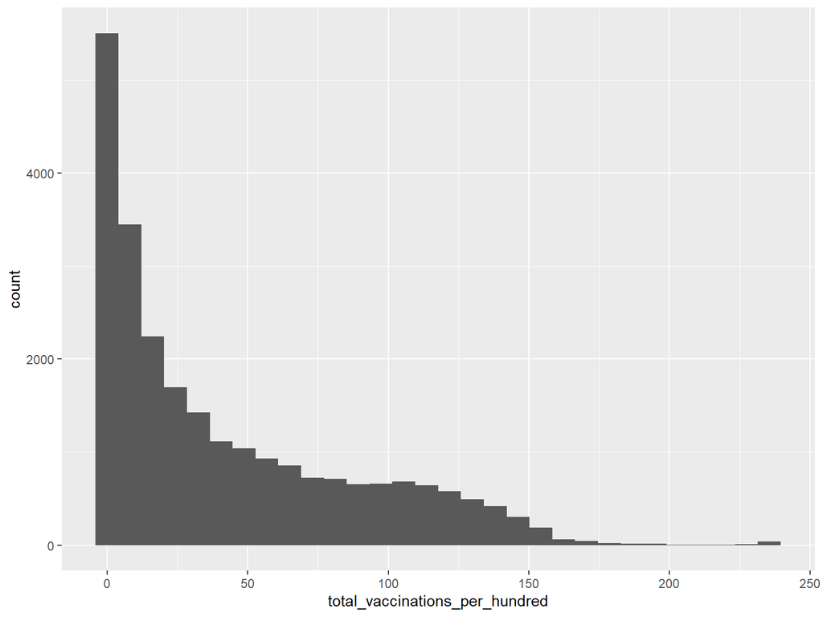

### Worldwide Vaccination Totals by Year

[figure not shown]

#### Which countries are on track to have vaccinated 40% of their population with at least 1 dose by the end of 2021?

Based on our international COVID-19 vaccination data, we have made projections of which countries are on track to achieve this.

We will update these projections weekly to continue to monitor global progress towards this goal.

#### How does Our World in Data calculate these projections?

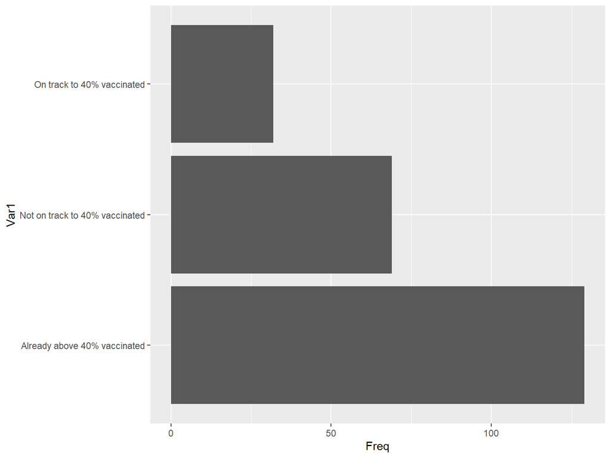

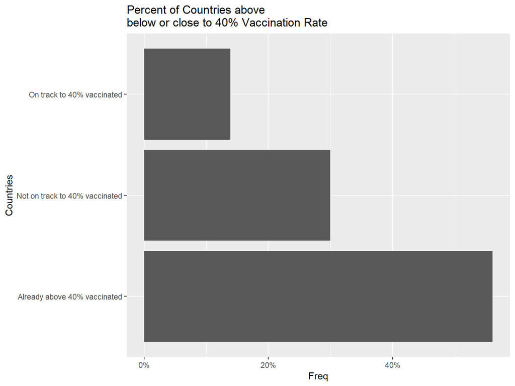

### Totals by Country

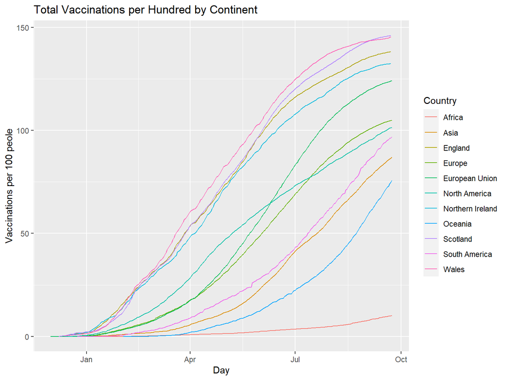

### Plot by Income Level

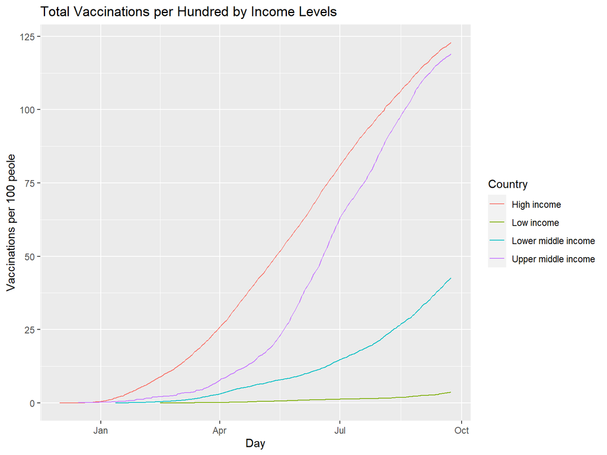